# Tuple

What is a Tuple in Python?

A Tuple in Python is an ordered, immutable sequence of elements. Think of it as a container for a fixed collection of items.

Key Characteristics of Python Tuples:

- Ordered: The items in a tuple have a specific order, and this order is maintained. Elements are accessed by index (0-based).
- Immutable (Unchangeable): Once a tuple is created, you cannot add, remove, or change its elements. This is the main distinction from lists.
- Allows Duplicates: Like lists, tuples can contain multiple items with the same value.
- Heterogeneous: A single tuple can contain items of different data types (e.g., numbers, strings, booleans).
- Fixed Size (in terms of elements): Because they are immutable, the number of elements in a tuple is fixed upon creation.

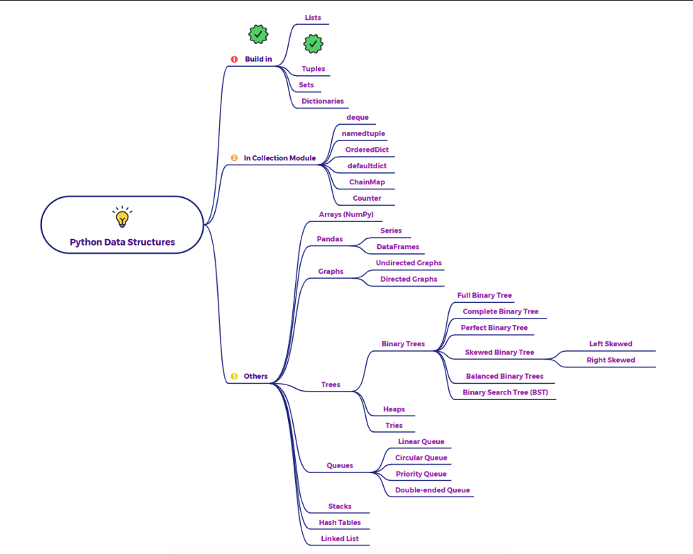

# 1. Define a Utility function to print highlighted characteristics

```python
import collections

def highlight_characteristic(name, description, symbol='='):
    """Helper function to print highlighted characteristics."""
    print(f"\n{symbol*5} {name.upper()} {symbol*5}")
    print(description)
    print(f"{symbol*5} {name.upper()} {symbol*5}\n")

print("--- Python Tuple Data Structure: Product Order Record Example ---")
```

```
--- Python Tuple Data Structure: Product Order Record Example ---
```

# 2. Exploring the Ordered nature of Tuple

Ordered:

- Elements are defined in a specific sequence (1001, "Laptop XYZ", ...).
- Accessing elements by their index (order_record[0], order_record[1]) always retrieves them in the same order, confirming their position is preserved.

```python
# 1. Ordered Characteristic

highlight_characteristic(
    "Ordered",
    "Elements in a tuple maintain their insertion order. The position of an element is significant and fixed."
)

# Creating an order record tuple
# Format: (Order ID, Product Name, Quantity, Price Per Unit, Customer ID)
order_record = (1001, "Laptop XYZ", 2, 1200.50, "CUST789")
print(f"Original Order Record Tuple: {order_record}")

print("\nAccessing elements by index (order is preserved):")
print(f"Order ID (index 0): {order_record[0]}")
print(f"Product Name (index 1): {order_record[1]}")
print(f"Quantity (index 2): {order_record[2]}")
print(f"Price Per Unit (index 3): {order_record[3]}")

# Another example to show order:
order_record_2 = ("Desk Lamp", 1, 35.99, 1002, "CUST790") # Different order of types
print(f"Another Order Record Tuple: {order_record_2}")
print(f"Order ID (index 3 here): {order_record_2[3]}")
```

```
===== ORDERED =====
Elements in a tuple maintain their insertion order. The position of an element is significant and fixed.
===== ORDERED =====

Original Order Record Tuple: (1001, 'Laptop XYZ', 2, 1200.5, 'CUST789')

Accessing elements by index (order is preserved):
Order ID (index 0): 1001
Product Name (index 1): Laptop XYZ
Quantity (index 2): 2
Price Per Unit (index 3): 1200.5
Another Order Record Tuple: ('Desk Lamp', 1, 35.99, 1002, 'CUST790')
Order ID (index 3 here): 1002
```